# P8106_hw2_yw4662

Ye Wen

2026-03-010

## Setup + Train/Test Split

```r
library(tidyverse)
college <- read_csv("./data/College.csv")
if (!is.numeric(college[[1]]) && anyDuplicated(college[[1]]) == 0) {
  rownames(college) <- college[[1]]
  college <- college[, -1]
}
set.seed(1)
n <- nrow(college)
train_id <- sample(1:n, size = floor(0.8*n), replace = FALSE)

train <- college[train_id, ]
test  <- college[-train_id, ]

y_train <- train$Outstate
y_test  <- test$Outstate
```

## Question a: Smoothing spline model

### Answer

As the degrees of freedom increase, the spline becomes more flexible. With low df, the fit is very smooth and looks close to a straight line, capturing only the overall upward trend of Outstate with Top10perc. With moderate df, the curve starts to pick up gentle curvature. At higher df, the fit becomes noticeably wiggly, especially in the mid-to-high Top10perc range, suggesting it may be chasing noise rather than the main signal.

I chose df=3. The selection criterion was cross-validation using using `smooth.spline`, which picked df-3 as minimizing the CV error.

### Code

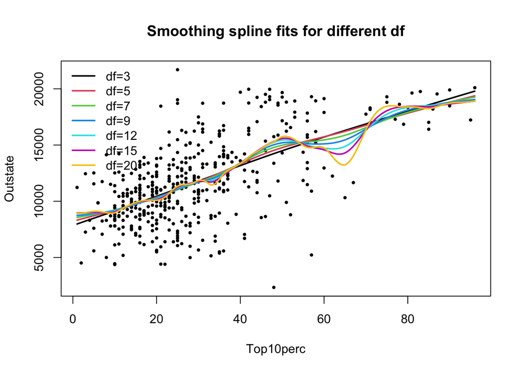

```r
# Fit splines for multiple df and plot curves

library(splines)

x <- train$Top10perc
x_grid <- seq(min(x), max(x), length.out = 200)

df_grid <- c(3, 5, 7, 9, 12, 15, 20)

plot(train$Top10perc, train$Outstate, pch=16, cex=0.6,
     xlab="Top10perc", ylab="Outstate",
     main="Smoothing spline fits for different df")

cols <- seq_along(df_grid)

for (k in seq_along(df_grid)) {
  fit_k <- smooth.spline(x = train$Top10perc, y = train$Outstate, df = df_grid[k])
  pred_k <- predict(fit_k, x = x_grid)$y
  lines(x_grid, pred_k, lwd=2, col=cols[k])
}

legend("topleft", legend=paste0("df=", df_grid), col=cols, lwd=2, bty="n")
```

```r
# Choose the df by minimizing cross-validated error

df_candidates <- 3:25

cv_mse <- sapply(df_candidates, function(d) {
  fit <- smooth.spline(x=train$Top10perc, y=train$Outstate, df=d, cv=TRUE)

  fit$cv.crit
})

best_df <- df_candidates[which.min(cv_mse)]
best_df
```

```
## [1] 3
```

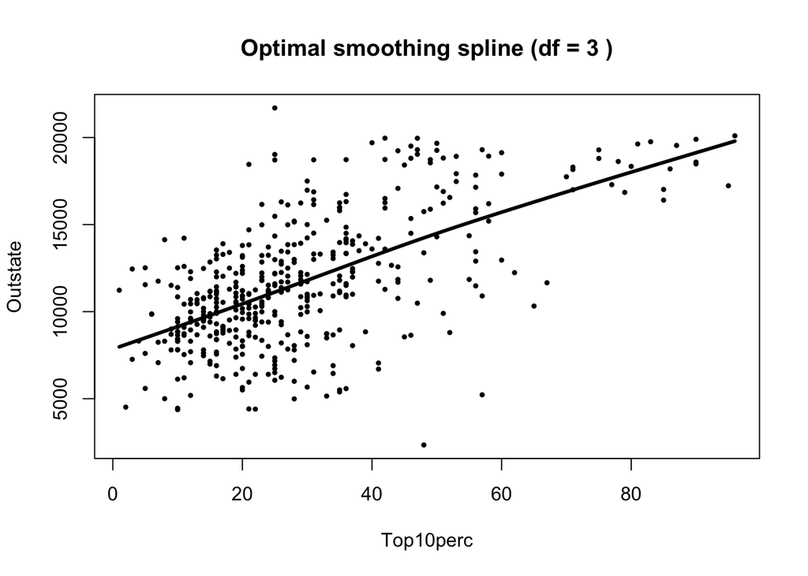

```r
fit_best <- smooth.spline(x=train$Top10perc, y=train$Outstate, df=best_df)

plot(train$Top10perc, train$Outstate, pch=16, cex=0.6,
     xlab="Top10perc", ylab="Outstate",
     main=paste("Optimal smoothing spline (df =", best_df, ")"))
lines(x_grid, predict(fit_best, x_grid)$y, lwd=3)
```

## Question b: MARS model

### Answer

The fitted MARS model can be written as $\widehat{Outstate}=10100.32+0.40097\,h(\text{Apps}-2694)-2.04034\,h(2081-\text{Accept})+4.95549\,h(942-\text{Enroll}) -1.47983\,h(1251-\text{F.Undergrad})-0.32893\,h(\text{F.Undergrad}-1251) -1.56650\,h(4138-\text{Room.Board})+0.83858\,h(1300-\text{Personal}) -88.96339\,h(21-\text{perc.alumni})+0.75266\,h(\text{Expend}-6898)-0.74075\,h(\text{Expend}-15494)-27.4719\,h(81-\text{Grad.Rate})$, where $h(t)=\max(t,0)$.

I plotted the partial dependence for an arbitrary predictor in the model using the MARS partial effects plot (see below).

On the test set, the model achieved $MSE = 2,831,844 (RMSE = 1,682.81)$.

### Code

```r
# Fit MARS on training data
library(earth)
```

```r
library(plotmo)

set.seed(1)
mars_fit <- earth(
  Outstate ~ .,
  data = train,
  degree = 1,
  nfold = 10
)

summary(mars_fit)
```

```
## Call: earth(formula=Outstate~., data=train, degree=1, nfold=10)
##
##                     coefficients
## (Intercept)           10100.3206
## h(Apps-2694)              0.4010
## h(2081-Accept)           -2.0403
## h(942-Enroll)             4.9555
## h(1251-F.Undergrad)      -1.4798
## h(F.Undergrad-1251)      -0.3289
## h(4138-Room.Board)       -1.5665
## h(1300-Personal)          0.8386
## h(21-perc.alumni)       -88.9634
## h(Expend-6898)            0.7527
## h(Expend-15494)          -0.7407
## h(81-Grad.Rate)         -27.4719
##
## Selected 12 of 22 terms, and 9 of 16 predictors
## Termination condition: RSq changed by less than 0.001 at 22 terms
## Importance: Expend, Grad.Rate, Room.Board, Accept, Enroll, perc.alumni, ...
## Number of terms at each degree of interaction: 1 11 (additive model)
## GCV 2874090  RSS 1170244288  GRSq 0.7904825  RSq 0.8104247  CVRSq 0.7458372
##
## Note: the cross-validation sd's below are standard deviations across folds
##
## Cross validation:   nterms 14.30 sd 2.41    nvars 9.50 sd 0.85
##
##      CVRSq    sd     MaxErr   sd
##      0.746 0.068       7374 5779
```

```r
# Report the regression function
format(mars_fit)
```

```
## [1] "  10100.32\n  +  0.4009703 * h(Apps-2694)\n  -   2.040344 * h(2081-Accept)\n  +   4.955488 * h(942-Enroll)\n  -   1.479827 * h(1251-F.Undergrad)\n  -  0.3289301 * h(F.Undergrad-1251)\n  -   1.566502 * h(4138-Room.Board)\n  +  0.8385822 * h(1300-Personal)\n  -   88.96339 * h(21-perc.alumni)\n…
```

```
##  plotmo grid:    Apps Accept Enroll Top10perc Top25perc F.Undergrad P.Undergrad
##                  1124    859  327.5        25        55      1270.5       215.5
##  Room.Board Books Personal PhD Terminal S.F.Ratio perc.alumni Expend Grad.Rate
##        4340   500     1100  73       80      12.8          25 8882.5        69
```

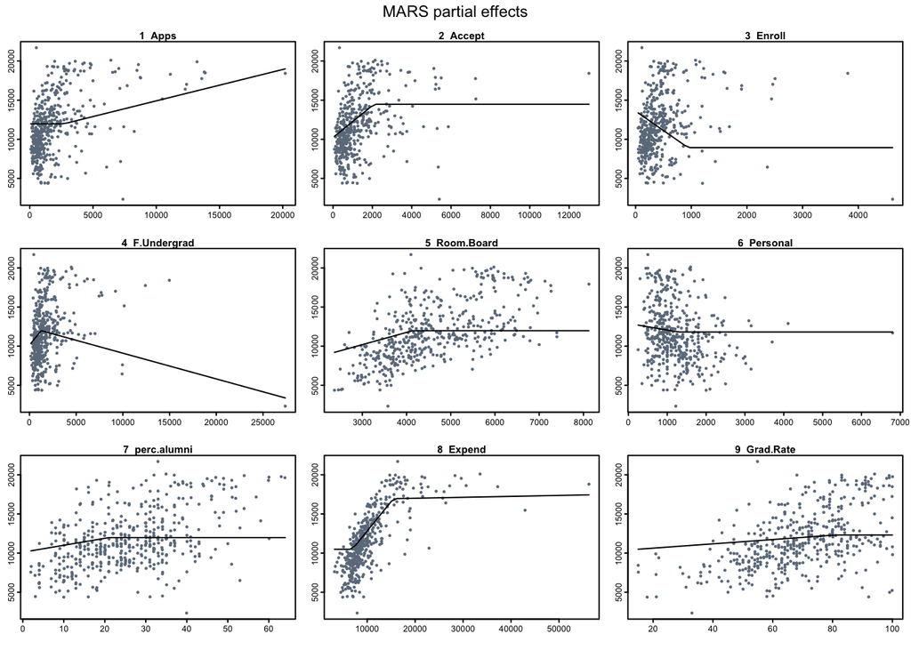

```r
# Partial dependence plot
plotmo(mars_fit, pch=16, cex=0.6, caption="MARS partial effects")
```

```r
# Test error
pred_mars <- predict(mars_fit, newdata = test)
mse_mars  <- mean((y_test - pred_mars)^2)
rmse_mars <- sqrt(mse_mars)

mse_mars
```

```
## [1] 2831844
```

```r
rmse_mars
```

```
## [1] 1682.808
```

## Question c: GAM model

### Answer

I plotted the partial dependence below.

On the test set, the GAM achieved $MSE = 2,743,197 (RMSE = 1,656.26)$.

### Code

```r
# Fit GAM
library(mgcv)
set.seed(1)
gam_fit <- gam(
  Outstate ~
    s(Top10perc) +
    s(Room.Board) +
    s(Expend) +
    s(Grad.Rate) +
    Apps + Accept + Enroll + Top25perc + F.Undergrad + P.Undergrad +
    Books + Personal + PhD + Terminal + S.F.Ratio + perc.alumni,
  data = train,
  method = "REML"
)

summary(gam_fit)
```

```
##
## Family: gaussian
## Link function: identity
##
## Formula:
## Outstate ~ s(Top10perc) + s(Room.Board) + s(Expend) + s(Grad.Rate) +
##     Apps + Accept + Enroll + Top25perc + F.Undergrad + P.Undergrad +
##     Books + Personal + PhD + Terminal + S.F.Ratio + perc.alumni
##
## Parametric coefficients:
##               Estimate Std. Error t value Pr(>|t|)
## (Intercept)  1.085e+04  9.465e+02  11.462  < 2e-16 ***
## Apps         2.344e-01  1.218e-01   1.925 0.054898 .
## Accept       7.819e-01  2.297e-01   3.404 0.000727 ***
## Enroll      -3.121e+00  8.667e-01  -3.601 0.000354 ***
## Top25perc   -5.356e+00  1.116e+01  -0.480 0.631485
## F.Undergrad -4.765e-03  1.305e-01  -0.037 0.970895
## P.Undergrad  8.569e-03  1.650e-01   0.052 0.958604
## Books       -3.754e-01  4.916e-01  -0.764 0.445511
## Personal    -3.692e-01  1.410e-01  -2.619 0.009130 **
## PhD          6.628e+00  9.841e+00   0.674 0.500969
## Terminal     3.922e+00  1.086e+01   0.361 0.718065
## S.F.Ratio    7.280e+00  3.372e+01   0.216 0.829161
## perc.alumni  3.398e+01  8.772e+00   3.874 0.000124 ***
## ---
## Signif. codes:  0 '***' 0.001 '**' 0.01 '*' 0.05 '.' 0.1 ' ' 1
##
## Approximate significance of smooth terms:
##                 edf Ref.df      F p-value
## s(Top10perc)  1.005  1.010  3.018 0.08276 .
## s(Room.Board) 3.282  4.157 10.692 < 2e-16 ***
## s(Expend)     6.546  7.688 21.064 < 2e-16 ***
## s(Grad.Rate)  2.244  2.852  5.668 0.00152 **
## ---
## Signif. codes:  0 '***' 0.001 '**' 0.01 '*' 0.05 '.' 0.1 ' ' 1
##
## R-sq.(adj) =  0.781   Deviance explained = 79.3%
## -REML = 3976.8  Scale est. = 3.0038e+06  n = 452
```

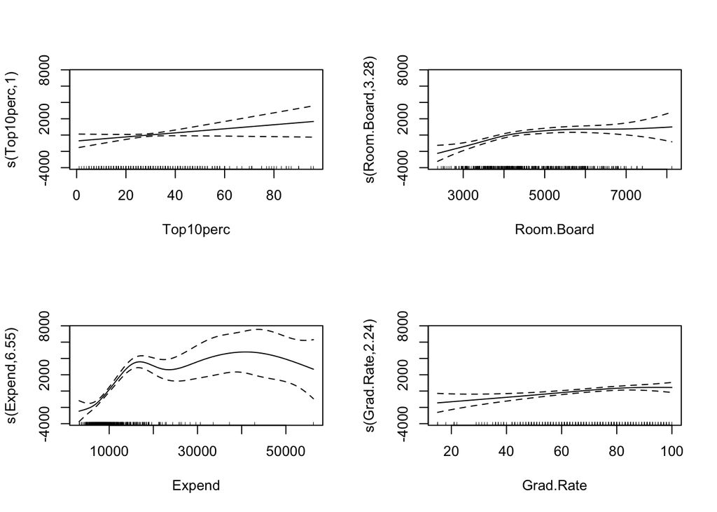

```r
# Plot nonlinear relationships
par(mfrow=c(2,2))
plot(gam_fit, shade = TRUE, seWithMean = TRUE)
```

```r
par(mfrow=c(1,1))

# Test error
pred_gam <- predict(gam_fit, newdata = test)
mse_gam  <- mean((y_test - pred_gam)^2)
rmse_gam <- sqrt(mse_gam)

mse_gam
```

```
## [1] 2743197
```

```r
rmse_gam
```

```
## [1] 1656.26
```

## Question d: MARS vs Linear model

### Answer

Yes, I would favor MARS for prediction here.

On the test set, MARS achieves a much lower error ($MSE=2,831,844$ and $RMSE=1,682.81$) than the baseline linear model ($MSE=3,866,573$ and $RMSE=1,966.36$), suggesting that there are important nonlinearities/threshold effects in the predictors that a linear model cannot capture.

### Code

```r
# Fit a baseline linear model
lm_fit <- lm(Outstate ~ ., data = train)
pred_lm <- predict(lm_fit, newdata = test)
mse_lm  <- mean((y_test - pred_lm)^2)
rmse_lm <- sqrt(mse_lm)

mse_lm
```

```
## [1] 3866573
```

```r
rmse_lm
```

```
## [1] 1966.36
```

## Question e

In real applications, MARS is not always preferred to a linear model, because there is a trade-off between predictive accuracy and interpretability/simplicity. Linear regression is usually the safer default because it is stable and easy to explain, while MARS is more flexible and can capture nonlinearities and threshold effects.

In this dataset, that extra flexibility is worthwhile: MARS substantially beats the linear baseline on the test set, so for prediction I would pick MARS here.